# Chapter 7, Part II: Fuel poverty measurement experiments

Torran Semple

02/25

#### Notebook description:

This notebook describes the fuel poverty measurements using the synthetic Nottingham homes (see Thesis: Chapter 7, Section 7.6).

## Overview of contents

1. Loading and cleaning synthetic data (i.e., the synthetic output of CH7, part I)
2. Calculate 10% Fuel Poverty (i.e. the Fuel Poverty Ratio): including basic 10%, 20% (i.e., ‘extreme’ fuel poverty) and five-fold 10%
3. Visualising five-level 10% fuel poverty
4. Calculate LIHC fuel poverty
5. Caculate LILEE* fuel poverty
6. Visualising fuel poverty according to various definitions for a subset of Nottingham LSOAs
7. LIHC and LILEE crosstabulations with 10% fuel poverty
8. Further five-level fuel poverty visualisations (LSOA susbet)
9. Calculating the (Hills) Fuel Poverty Gap
10. Calculating the *novel* 10% and 8% (“precarity”) fuel poverty gap
11. Calculating MIS-based Fuel Poverty: including MIS + 10% and MIS + five-level 10% + fuel poverty gap/buffer
12. The closeness of LILEE* and DESNZ LILEE statistics

## Set working directory, load/install required packages and package dependencies

```r
# Note: set the working directory to the source file location; for example:
setwd("~/Desktop/thesis_supplementary_material/Chapter_7/II")

# Install required packages if necessary
if(!require(tidyverse)) install.packages("tidyverse")
if(!require(sqldf)) install.packages("sqldf")

# Load required packages
library(tidyverse)
library(sqldf)

# Dependencies - shows R and package versions used in original analysis
```

## 1. Loading and cleaning synthetic data (i.e., the synthetic output of CH7, part I)

```r
# Load synthetic Nottingham homes data (i.e., synthetic_nottingham_homes.csv)
synth <- read.csv("Data/synthetic_nottingham_homes.csv", header = TRUE, sep = ",")


# clean: convert any obscure 'INVALID!' observations to NAs and remove
synth <- synth %>% # from hereon, the synthetic Nottingham homes are referred to by the shorthand 'synth'
  mutate(
    current_energy_rating = na_if(current_energy_rating, "INVALID!")
  )

synth <- na.omit(synth) # note: only 1 such case


# synth needs EPC A-C versus D-G column for later experiments
synth <- synth %>%
  mutate(epc_agg = case_when(
    current_energy_rating %in% c("A", "B", "C") ~ "A-C",
    current_energy_rating %in% c("D", "E", "F", "G") ~ "D-G",
    TRUE ~ NA_character_
  ))


# synth also needs to be merged with with IMD data (sourced from https://www.gov.uk/government/collections/english-indices-of-deprivation) for later visuals
imd <- read.csv("Data/notts_imd.csv", header = TRUE, sep = ",")
colnames(imd) <- tolower(colnames(imd))
colnames(imd)[1] <- "lsoa_2011"
synth <- left_join(synth, imd, by = "lsoa_2011")

# For consistency with previous code (i.e., CH7 part I), aggregate the IMD deciles to IMD quintiles
synth$imd_quintile <- ifelse(synth$imd_decile %in% c(1, 2), 1,
                           ifelse(synth$imd_decile %in% c(3, 4), 2,
                                  ifelse(synth$imd_decile %in% c(5, 6), 3,
                                         ifelse(synth$imd_decile %in% c(7, 8), 4, 5))))
```

## 2. Calculate 10% Fuel Poverty (i.e. the Fuel Poverty Ratio): including basic 10%, 20% (i.e., ‘extreme’ fuel poverty) and five-fold 10%

```r
# Create a new column called 'fuel_poverty_ratio' (energy costs divided by income multiplied by 100)
synth <- synth %>%
    mutate(fuel_poverty_ratio = energy_costs / income * 100)

# Using the fuel poverty ratio, create new columns for 10% and 20% (extreme) fuel poverty
synth <- synth %>%
  mutate(categorical_10 = ifelse(fuel_poverty_ratio >= 10.0, 1, 0))  # 10% fuel poverty rate of 36.83% across the synthetic Nottingham sample
synth <- synth %>%
  mutate(categorical_20 = ifelse(fuel_poverty_ratio >= 20.0, 1, 0))  # 20% fuel poverty (i.e., 'extreme fuel poverty' according to Scottish Gov.) rate of 5.74% across the synthetic Nottingham sample



# Extend further to five-level/fold 10% (where 'not fuel poor' = <8%; 'marginal fuel poverty' = 8-10%; 'fuel poverty' = 10-13%; 'severe fuel poverty' = 13-20% and 'extreme fuel poverty' = >20%)

synth <- synth %>%
  mutate(
    five_level_10 = case_when(
      fuel_poverty_ratio < 8.0  ~ "Not fuel poor (<8%)",
      fuel_poverty_ratio >= 8.0 & fuel_poverty_ratio <= 10.0 ~ "Marginal fuel poverty (8-10%)",
      fuel_poverty_ratio > 10.0 & fuel_poverty_ratio <= 13.0 ~ "Fuel poverty (10-13%)",
      fuel_poverty_ratio > 13.0 & fuel_poverty_ratio <= 20.0 ~ "Severe fuel poverty (13-20%)",
      fuel_poverty_ratio > 20.0  ~ "Extreme fuel poverty (>20%)",
      TRUE ~ NA_character_
    )
  )


# Create summary statistics for 10%, 20%, and five-level 10% per LSOA (Note: have lost 18 LSOAs due to incompatibility between epc and synth (i.e., GDHI) LSOAs)
LSOA_summary_fp <- synth %>%
  group_by(lsoa_2011) %>%
  summarise(
    cumulative_proportion_above_10 = mean(fuel_poverty_ratio >= 10, na.rm = TRUE)
  )

summary_20 <- synth %>%
  group_by(lsoa_2011) %>%
  summarise(
    proportion_above_20 = mean(fuel_poverty_ratio >= 20, na.rm = TRUE)
  )


# Join tables
LSOA_summary_fp <- left_join(LSOA_summary_fp, summary_20, by = "lsoa_2011")
```

## 3. Visualising five-level 10% fuel poverty

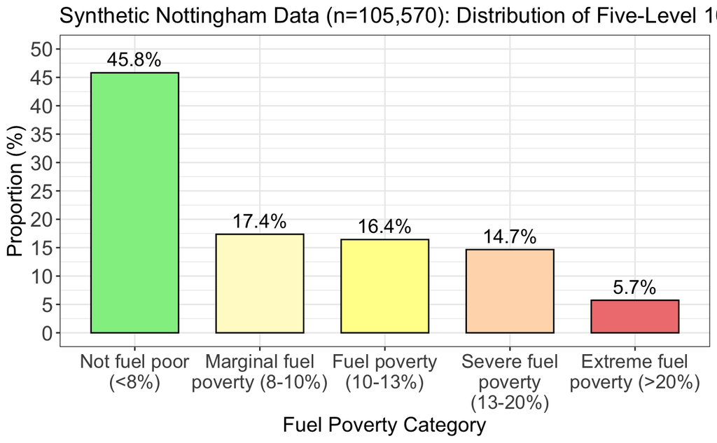

```r
# Define the order of five-level 10%
category_order <- c("Not fuel poor (<8%)", "Marginal fuel poverty (8-10%)", "Fuel poverty (10-13%)",
                    "Severe fuel poverty (13-20%)", "Extreme fuel poverty (>20%)")

# Calculate proportions and set factor levels
category_proportions <- synth %>%
  group_by(five_level_10) %>%
  summarise(count = n()) %>%
  mutate(proportion = count / sum(count)*100) %>%
  mutate(five_level_10 = factor(five_level_10, levels = category_order)) # Convert to factor with specified order

# Define colour scale
color_scale <- c("Not fuel poor (<8%)" = "#90EE90",  # Light Green
                 "Marginal fuel poverty (8-10%)" = "#FFFACD", # Light Yellow
                 "Fuel poverty (10-13%)" = "#FFFF99",  # Slightly darker yellow
                 "Severe fuel poverty (13-20%)" = "#FFDAB9",  # Light Orange
                 "Extreme fuel poverty (>20%)" = "#F08080") # Light Red

# Create five-level 10% bar plot (ggplot2)
x1 <- ggplot(category_proportions, aes(x = five_level_10, y = proportion, fill = five_level_10)) +
  geom_bar(stat = "identity", width = 0.7, color = "black") +
  geom_text(aes(label = paste0(round(proportion, 1), "%")), vjust = -0.5, color = "black", size = 5) + # Adjusted geom_text
  labs(
    x = "Fuel Poverty Category",
    y = "Proportion (%)",
    title = "Synthetic Nottingham Data (n=105,570): Distribution of Five-Level 10% Fuel Poverty"
  ) +
  scale_y_continuous(breaks = seq(0, 50, 5), limits = c(0, 50)) +
  scale_x_discrete(labels = function(x) str_wrap(x, width = 15)) +
  scale_fill_manual(values = color_scale) +
  theme_bw() +
  theme(
    text = element_text(family = "Arial", size = 10),
    axis.text.x = element_text(size = 14),
    axis.text.y = element_text(size = 15),
    plot.title = element_text(size = 16),
    axis.title.x = element_text(size = 15),
    axis.title.y = element_text(size = 15),
    legend.position = "none"
  )

x1
```

```r
# Further categories for LSOA summary stats table: not fuel poor, marginal, fuel poor (10-13 specifically) and severe

# Not fuel poor
summary_under_8 <- synth %>%
  group_by(lsoa_2011) %>%
  summarise(
    proportion_under_8 = mean(fuel_poverty_ratio < 8, na.rm = TRUE)
  )

# Marginal fuel poverty
summary_marg_8_10 <- synth %>%
  group_by(lsoa_2011) %>%
  summarise(
   proportion_marg_8_10 = mean(fuel_poverty_ratio >= 8 & fuel_poverty_ratio < 10, na.rm = TRUE)
  )

# Fuel poverty (10-13 only)
summary_fp_10_13 <- synth %>%
  group_by(lsoa_2011) %>%
  summarise(
   proportion_fp_10_13 = mean(fuel_poverty_ratio >= 10 & fuel_poverty_ratio < 13, na.rm = TRUE)
  )

# Severe fuel poverty
summary_severe_13_20 <- synth %>%
  group_by(lsoa_2011) %>%
  summarise(
   proportion_severe_13_20 = mean(fuel_poverty_ratio >= 13 & fuel_poverty_ratio < 20, na.rm = TRUE)
  )


# Join summary tables
LSOA_summary_fp <- left_join(LSOA_summary_fp, summary_under_8, by = "lsoa_2011")
LSOA_summary_fp <- left_join(LSOA_summary_fp, summary_marg_8_10, by = "lsoa_2011")
LSOA_summary_fp <- left_join(LSOA_summary_fp, summary_fp_10_13, by = "lsoa_2011")
LSOA_summary_fp <- left_join(LSOA_summary_fp, summary_severe_13_20, by = "lsoa_2011")
```

## 4. Calculate LIHC fuel poverty

```r
# Calculate LIHC fuel poverty among the synthetic Nottingham homes
synth <- synth %>%
  mutate(LIHC = ifelse(energy_costs > 2252 & income < 18840 + energy_costs, 1, 0)) # where £2252 is median energy costs and £18840 is the 2021 poverty line; note: the 2021 poverty line is used here for greatest harmony with GDHI estimates that were used to generate the synthetic Nottingham homes
table(synth$LIHC) # LIHC rate of 10.26%
```

```
    0     1
94743 10827
```

```r
# LIHC_2: i.e., assuming more recent 2023 poverty line (20,700)
synth <- synth %>%
  mutate(LIHC_2 = ifelse(energy_costs > 2252 & income < 20700 + energy_costs, 1, 0))
table(synth$LIHC_2) # LIHC_2 rate of 12.47%
```

```
    0     1
92403 13167
```

```r
# LIHC per LSOA
summary_lihc <- synth %>%
  group_by(lsoa_2011) %>%
  summarise(
   proportion_lihc = mean(LIHC, na.rm = TRUE)
  )


# Join to summary table
LSOA_summary_fp <- left_join(LSOA_summary_fp, summary_lihc, by = "lsoa_2011")
```

## 5. Caculate LILEE* fuel poverty

```r
# Note: LILEE is referred to as LILEE* in this case, as SAP is used as opposed to FPEER; regardless, SAP and FPEER are equal in the vast majority of cases.

# first create new column - poverty line 2021 (18840) then calculate poverty line + energy costs
synth <- synth %>%
  mutate(pov_line_2021 = 18840)

# poverty line 2021 adjusted for energy costs (i.e. poverty line + energy costs)
synth <- synth %>%
  mutate(pov_line_2021_energy_costs = pov_line_2021 + energy_costs)

# LILEE* classification
synth <- synth %>%
  mutate(LILEE = ifelse(current_energy_efficiency < 69 & income < pov_line_2021_energy_costs, 1, 0))
table(synth$LILEE) # 18.3% fuel poor according to LILEE*
```

```
    0     1
86252 19318
```

```r
# Calculate LILEE*2 (i.e., 2023 poverty line - )

# 2023 poverty line = 20700
synth <- synth %>%
  mutate(pov_line_2023 = 20700)

# poverty line 2023 + energy costs
synth <- synth %>%
  mutate(pov_line_2023_energy_costs = pov_line_2023 + energy_costs)

# LILEE*2 classification
synth <- synth %>%
  mutate(LILEE_2 = ifelse(current_energy_efficiency < 69 & income < pov_line_2023_energy_costs, 1, 0))

table(synth$LILEE_2) # 21.59% fuel poor according to LILEE*2
```

```
    0     1
82781 22789
```

```r
# LILEE* per LSOA summary
summary_lilee <- synth %>%
  group_by(lsoa_2011) %>%
  summarise(
   proportion_lilee = mean(LILEE, na.rm = TRUE)
  )

# Join to summary table
LSOA_summary_fp <- left_join(LSOA_summary_fp, summary_lilee, by = "lsoa_2011")
```

## 6. Visualising fuel poverty according to various definitions for a subset of Nottingham LSOAs

```r
# create synth_lsoa_subset (note: these LSOAs were selected at random)
lsoa_values_to_keep <- c("E01013979", "E01013983", "E01013931", "E01013965",
                          "E01013977", "E01013893", "E01013897", "E01013856",
                          "E01013934", "E01013984", "E01033398")
synth_lsoa_subset <- synth %>%
  filter(lsoa_2011 %in% lsoa_values_to_keep)

# check all LSOAs are present
table(synth_lsoa_subset$lsoa_2011)
```

```
E01013856 E01013893 E01013931 E01013934 E01013965 E01013977 E01013979 E01013983 E01013984 E01033398
      569       619       592       578       521       486       391       553       378       626
```

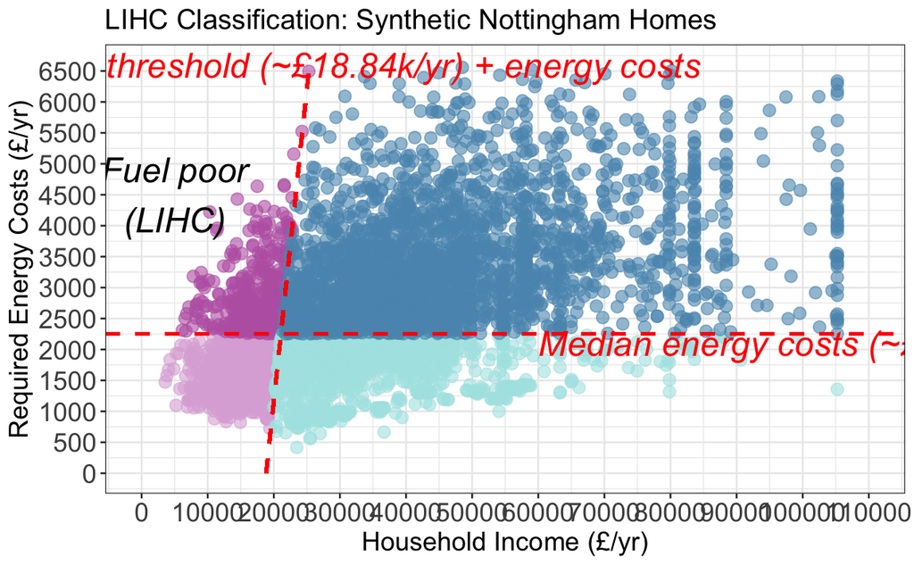

```r
# ----------------------------------------------------------------------------------------------------------
# ----------------------------------------------------------------------------------------------------------
# 1. LIHC fuel poverty classification scatter plot
# ----------------------------------------------------------------------------------------------------------
# ----------------------------------------------------------------------------------------------------------

# first specify conditions for LILC, LIHC, HILC and HIHC homes (sqldf)
LILC <- sqldf("SELECT * FROM synth_lsoa_subset WHERE income < 18840 + energy_costs AND energy_costs < 2252")
LIHC <- sqldf("SELECT * FROM synth_lsoa_subset WHERE income < 18840 + energy_costs AND energy_costs >= 2252")
HILC <- sqldf("SELECT * FROM synth_lsoa_subset WHERE income >= 18840 + energy_costs AND energy_costs < 2252")
HIHC <- sqldf("SELECT * FROM synth_lsoa_subset WHERE income >= 18840 + energy_costs AND energy_costs >= 2252")

p1 <- ggplot(synth_lsoa_subset, aes(x = income, y = energy_costs)) +
  geom_point(data=LILC, size=3, colour= "#DDB0D9", alpha = 0.6) + # geom_point specifies colours for all quadrants
  geom_point(data=LIHC, size=3, colour= "#BB64B1", alpha = 0.6) +
  geom_point(data=HILC, size=3, colour="#ACE4E4", alpha = 0.6) +
  geom_point(data=HIHC, size=3, colour="#5A97BC", alpha = 0.6) +
  labs(title = "LIHC Classification: Synthetic Nottingham Homes",
       x = "Household Income (£/yr)",
       y = "Required Energy Costs (£/yr)") +
  theme_bw() +
  geom_segment(aes(x = 18840, y = 0, xend = 25290, yend = 6500), # geom_segment/geom_hline add the intersecting red lines (i.e., poverty thresholds)
               color = "red", linetype = "dashed", linewidth = 1) +
  geom_hline(yintercept = 2252, color = "red", linetype = "dashed", linewidth = 1) +
  scale_x_continuous(breaks = seq(0, 110000, 10000), limits = c(0, 110000)) +
  scale_y_continuous(breaks = seq(0, 6500, 500), limits = c(0, 6600)) +
  theme(axis.text.x = element_text(size = 15),
        axis.text.y = element_text(size = 15),
        legend.text = element_text(size = 15),
        plot.title = element_text(size = 16),
        axis.title.x = element_text(size = 15),
        axis.title.y = element_text(size = 15),
        legend.position = "none") +
  annotate("text", x = 5000, y = 4500, label = str_wrap("Fuel poor (LIHC)", width = 10), size = 7, color = "black", fontface = "italic") +
  annotate("text", x = 99000, y = 2100, label = "Median energy costs (~£2.25k/yr)", size = 7, color = "red", fontface = "italic") +
  annotate("text", x = 30000, y = 6600, label = "Poverty threshold (~£18.84k/yr) + energy costs", size = 7, color = "red", fontface = "italic")

p1 # homes in the 'LIHC' quadrant are considered fuel poor according to the LIHC definition
```

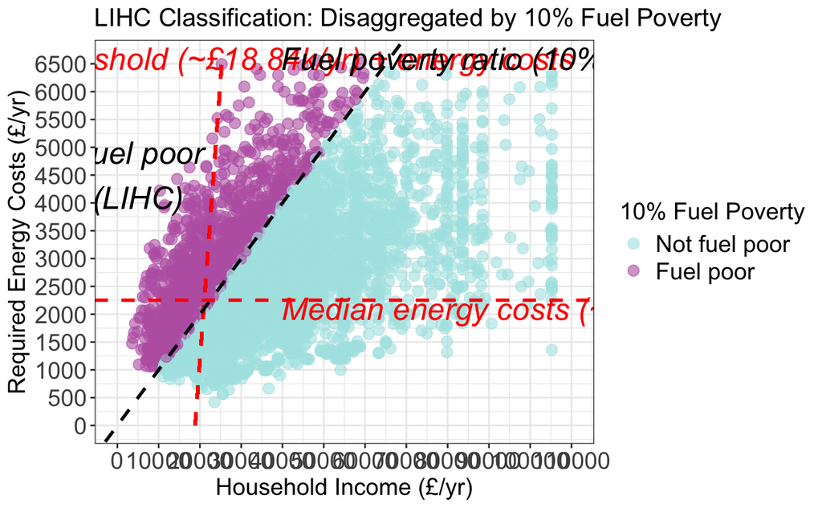

```r
# ----------------------------------------------------------------------------------------------------------
# ----------------------------------------------------------------------------------------------------------
# 2. LIHC fuel poverty classification scatter plot disaggregated by 10% fuel poverty status
# ----------------------------------------------------------------------------------------------------------
# ----------------------------------------------------------------------------------------------------------

p2 <- ggplot(synth_lsoa_subset, aes(x = income, y = energy_costs, color = factor(categorical_10))) +
  geom_point(size = 3, alpha = 0.6) +
  labs(title = "LIHC Classification: Disaggregated by 10% Fuel Poverty",
       x = "Household Income (£/yr)",
       y = "Required Energy Costs (£/yr)",
       color = "10% Fuel Poverty") +
  theme_bw() +
  geom_segment(aes(x = 18840, y = 0, xend = 25290, yend = 6500),
               color = "red", linetype = "dashed", linewidth = 1) +
  geom_hline(yintercept = 2252, color = "red", linetype = "dashed", linewidth = 1) +
  scale_x_continuous(breaks = seq(0, 110000, 10000), limits = c(0, 110000)) +
  scale_y_continuous(breaks = seq(0, 6500, 500), limits = c(0, 6600)) +
  theme(axis.text.x = element_text(size = 15),
        axis.text.y = element_text(size = 15),
        legend.text = element_text(size = 15),
        legend.title = element_text(size = 15),
        plot.title = element_text(size = 16),
        axis.title.x = element_text(size = 15),
        axis.title.y = element_text(size = 15)) +
  annotate("text", x = 5000, y = 4500, label = str_wrap("Fuel poor (LIHC)", width = 10), size = 7, color = "black", fontface = "italic") +
  scale_color_manual(values = c("0" = "#ACE4E4", "1" = "#BB64B1"),
                      labels = c("0" = "Not fuel poor", "1" = "Fuel poor")) +
  geom_abline(intercept = 0, slope = (6500/65000), linetype = "dashed", color = "black", linewidth=1) +
  annotate("text", x = 96000, y = 2100, label = "Median energy costs (~£2.25k/yr)", size = 7, color = "red", fontface = "italic") +
  annotate("text", x = 32000, y = 6600, label = "Poverty threshold (~£18.84k/yr) + energy costs", size = 7, color = "red", fontface = "italic") +
  annotate("text", x = 80000, y = 6600, label = "Fuel poverty ratio (10%)", size = 7, color = "black", fontface = "italic")

p2
```

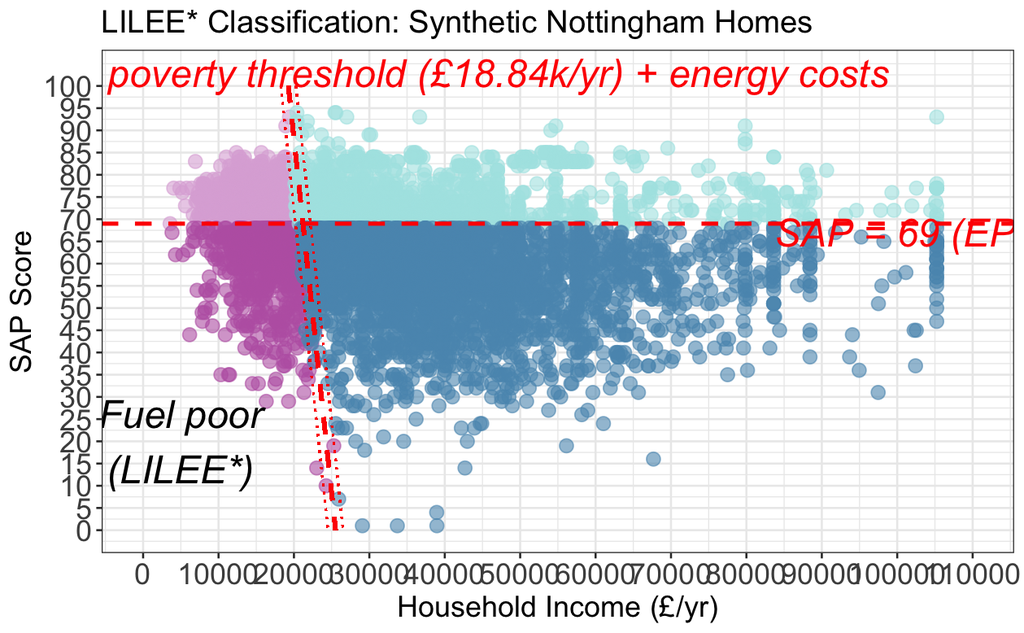

```r
# ----------------------------------------------------------------------------------------------------------
# ----------------------------------------------------------------------------------------------------------
# 3. LILEE* fuel poverty classification scatter plot
# ----------------------------------------------------------------------------------------------------------
# ----------------------------------------------------------------------------------------------------------

# first specify conditions for LILEE, LIHEE, HILEE and HIHEE homes (sqldf)
LILEE <- sqldf("SELECT * FROM synth_lsoa_subset WHERE current_energy_efficiency < 69 AND income < pov_line_2021_energy_costs")
LIHEE <- sqldf("SELECT * FROM synth_lsoa_subset WHERE current_energy_efficiency >= 69 AND income < pov_line_2021_energy_costs")
HILEE <- sqldf("SELECT * FROM synth_lsoa_subset WHERE current_energy_efficiency < 69 AND income >= pov_line_2021_energy_costs")
HIHEE <- sqldf("SELECT * FROM synth_lsoa_subset WHERE current_energy_efficiency >= 69 AND income >= pov_line_2021_energy_costs")

p3 <- ggplot(synth_lsoa_subset, aes(x = income, y = current_energy_efficiency)) +
  geom_point(data = LIHEE, size = 3, colour = "#DDB0D9", alpha = 0.6) + # geom_point specifies colours for all quadrants
  geom_point(data = LILEE, size = 3, colour = "#BB64B1", alpha = 0.6) +
  geom_point(data = HIHEE, size = 3, colour = "#ACE4E4", alpha = 0.6) +
  geom_point(data = HILEE, size = 3, colour = "#5A97BC", alpha = 0.6) +
  labs(title = "LILEE* Classification: Synthetic Nottingham Homes",
       x = "Household Income (£/yr)",
       y = "SAP Score") +
  theme_bw() +
  geom_hline(yintercept = 69, color = "red", linetype = "dashed", linewidth = 1) +
  scale_x_continuous(breaks = seq(0, 110000, 10000), limits = c(0, 110000)) +
  scale_y_continuous(breaks = seq(0, 100, 5), limits = c(0, 103)) +
  theme(axis.text.x = element_text(size = 15),
        axis.text.y = element_text(size = 15),
        legend.text = element_text(size = 15),
        plot.title = element_text(size = 16),
        axis.title.x = element_text(size = 15),
        axis.title.y = element_text(size = 15),
        legend.position = "none") +
  annotate("text", x = 5000, y = 20, label = str_wrap("Fuel poor (LILEE*)", width = 10), size = 7, color = "black", fontface = "italic") +
  annotate("text", x = 105000, y = 67, label = "SAP = 69 (EPC C)", size = 7, color = "red", fontface = "italic") +
  annotate("text", x = 34000, y = 103, label = "Diagonal = poverty threshold (£18.84k/yr) + energy costs", size = 7, color = "red", fontface = "italic") +
  geom_segment(aes(x = 18258, y = 100, xend = 24522, yend = 0),
               color = "red", linetype = "dotted", linewidth = 0.5) +
  geom_segment(aes(x = 19258, y = 100, xend = 25522, yend = 0),
               color = "red", linetype = "dashed", linewidth = 1) +
  geom_segment(aes(x = 20258, y = 100, xend = 26522, yend = 0),
               color = "red", linetype = "dotted", linewidth = 0.5)

p3
```

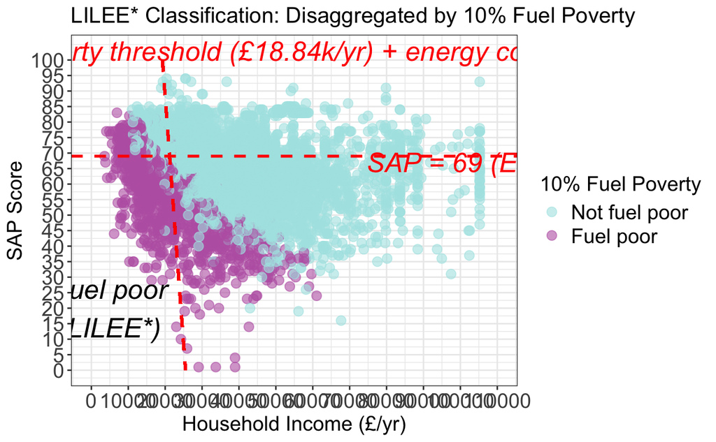

```r
# ----------------------------------------------------------------------------------------------------------
# ----------------------------------------------------------------------------------------------------------
# 4. LILEE* fuel poverty classification scatter plot disaggregated by 10% fuel poverty status
# ----------------------------------------------------------------------------------------------------------
# ----------------------------------------------------------------------------------------------------------

p4 <- ggplot(synth_lsoa_subset, aes(x = income, y = current_energy_efficiency, color = factor(categorical_10))) +
  geom_point(size = 3, alpha = 0.6) +
  labs(title = "LILEE* Classification: Disaggregated by 10% Fuel Poverty",
       x = "Household Income (£/yr)",
       y = "SAP Score",
       color = "10% Fuel Poverty") +
  theme_bw() +
  geom_hline(yintercept = 69, color = "red", linetype = "dashed", linewidth = 1) +
  scale_x_continuous(breaks = seq(0, 110000, 10000), limits = c(0, 110000)) +
  scale_y_continuous(breaks = seq(0, 100, 5), limits = c(0, 103)) +
  theme(axis.text.x = element_text(size = 15),
        axis.text.y = element_text(size = 15),
        legend.text = element_text(size = 15),
        legend.title = element_text(size = 15),
        plot.title = element_text(size = 16),
        axis.title.x = element_text(size = 15),
        axis.title.y = element_text(size = 15)) +
  scale_color_manual(values = c("0" = "#ACE4E4", "1" = "#BB64B1"),
                      labels = c("0" = "Not fuel poor", "1" = "Fuel poor")) +
 annotate("text", x = 5000, y = 20, label = str_wrap("Fuel poor (LILEE*)", width = 10), size = 7, color = "black", fontface = "italic") +
  annotate("text", x = 105000, y = 67, label = "SAP = 69 (EPC C)", size = 7, color = "red", fontface = "italic") +
  annotate("text", x = 34000, y = 103, label = "Diagonal = poverty threshold (£18.84k/yr) + energy costs", size = 7, color = "red", fontface = "italic") +
  geom_segment(aes(x = 19258, y = 100, xend = 25522, yend = 0),
               color = "red", linetype = "dashed", linewidth = 1)

p4 # homes in the 'LILEE' quadrant are considered fuel poor according to the LIHC definition
```

```r
NA
NA
```

## 7. LIHC and LILEE crosstabulations with 10% fuel poverty

```r
# Crosstabs can show the specific proportion of 10% fuel poverty per quadrant (e.g., LILC, LIHC, HILC, HIHC) in the previous figures

# LIHC
LILC_all <- sqldf("SELECT * FROM synth WHERE income < 18840 + energy_costs AND energy_costs < 2252")
LIHC_all <- sqldf("SELECT * FROM synth WHERE income < 18840 + energy_costs AND energy_costs >= 2252")
HILC_all <- sqldf("SELECT * FROM synth WHERE income >= 18840 + energy_costs AND energy_costs < 2252")
HIHC_all <- sqldf("SELECT * FROM synth WHERE income >= 18840 + energy_costs AND energy_costs >= 2252")

# LIHC tables
table(LILC_all$categorical_10)
```

```
    0     1
 9610 16641
```

```r
table(LIHC_all$categorical_10)
```

```
    1
10827
```

```r
table(HILC_all$categorical_10)
```

```
    0     1
29211   161
```

```r
table(HIHC_all$categorical_10)
```

```
    0     1
27867 11253
```

```r
#LILEE
LILEE_all <- sqldf("SELECT * FROM synth WHERE current_energy_efficiency < 69 AND income < pov_line_2021_energy_costs")
LIHEE_all <- sqldf("SELECT * FROM synth WHERE current_energy_efficiency >= 69 AND income < pov_line_2021_energy_costs")
HILEE_all <- sqldf("SELECT * FROM synth WHERE current_energy_efficiency < 69 AND income >= pov_line_2021_energy_costs")
HIHEE_all <- sqldf("SELECT * FROM synth WHERE current_energy_efficiency >= 69 AND income >= pov_line_2021_energy_costs")

# LIHC tables
table(LILEE_all$categorical_10)
```

```
    0     1
 1154 18164
```

```r
table(LIHEE_all$categorical_10)
```

```
   0    1
8456 9304
```

```r
table(HILEE_all$categorical_10)
```

```
    0     1
33304 11262
```

```r
table(HIHEE_all$categorical_10)
```

```
    0     1
23774   152
```

## 8. Further five-level fuel poverty visualisations (LSOA susbet)

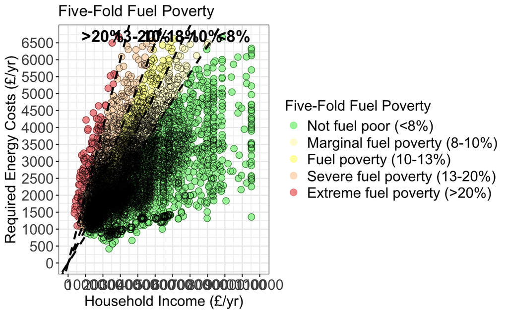

```r
# ----------------------------------------------------------------------------------------------------------
# ----------------------------------------------------------------------------------------------------------
# 1. Five-level fuel poverty (scatter)
# ----------------------------------------------------------------------------------------------------------
# ----------------------------------------------------------------------------------------------------------

level_order <- c(
  "Not fuel poor (<8%)",
  "Marginal fuel poverty (8-10%)",
  "Fuel poverty (10-13%)",
  "Severe fuel poverty (13-20%)",
  "Extreme fuel poverty (>20%)"
)

fl1 <- ggplot(synth_lsoa_subset, aes(x = income, y = energy_costs, color = factor(five_level_10, levels = level_order))) +
  geom_point(size = 3, alpha = 0.8) +
  geom_point(size = 3, alpha = 0.8, shape = 21, stroke = 0.25, color = "black") +
  labs(title = "Five-Fold Fuel Poverty",
       x = "Household Income (£/yr)",
       y = "Required Energy Costs (£/yr)",
       color = "Five-Fold Fuel Poverty") +
  theme_bw() +
  scale_x_continuous(breaks = seq(0, 110000, 10000), limits = c(0, 110000)) +
  scale_y_continuous(breaks = seq(0, 6500, 500), limits = c(0, 6700)) +
  theme(axis.text.x = element_text(size = 15),
        axis.text.y = element_text(size = 15),
        legend.text = element_text(size = 15),
        legend.title = element_text(size = 15),
        plot.title = element_text(size = 16),
        axis.title.x = element_text(size = 15),
        axis.title.y = element_text(size = 15)) +
  scale_color_manual(values = c("Not fuel poor (<8%)" = "#90EE90",
                               "Marginal fuel poverty (8-10%)" = "#FFFACD",
                               "Fuel poverty (10-13%)" = "#FFFF99",
                               "Severe fuel poverty (13-20%)" = "#FFDAB9",
                               "Extreme fuel poverty (>20%)" = "#F08080")) +
  geom_abline(intercept = 0, slope = (8/100), linetype = "dashed", color = "black", linewidth = 1) +
  geom_abline(intercept = 0, slope = (10/100), linetype = "dashed", color = "black", linewidth = 1) +
  geom_abline(intercept = 0, slope = (13/100), linetype = "dashed", color = "black", linewidth = 1) +
  geom_abline(intercept = 0, slope = (20/100), linetype = "dashed", color = "black", linewidth = 1) +
  annotate("text", x = 95000, y = 6700, label = "<8%", size = 6, color = "black", fontface = "bold") +
  annotate("text", x = 75000, y = 6700, label = "8-10%", size = 6, color = "black", fontface = "bold") +
  annotate("text", x = 59000, y = 6700, label = "10-13%", size = 6, color = "black", fontface = "bold") +
  annotate("text", x = 42500, y = 6700, label = "13-20%", size = 6, color = "black", fontface = "bold") +
  annotate("text", x = 20000, y = 6700, label = ">20%", size = 6, color = "black", fontface = "bold")

fl1
```

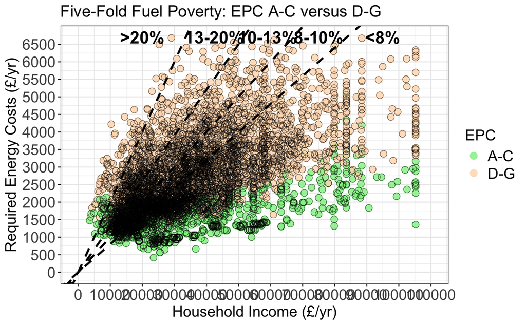

```r
# ----------------------------------------------------------------------------------------------------------
# ----------------------------------------------------------------------------------------------------------
# 2. Five-level fuel poverty disaggregated by aggregate EPC (i.e., A-C versus D-G)
# ----------------------------------------------------------------------------------------------------------
# ----------------------------------------------------------------------------------------------------------

fl2 <- ggplot(synth_lsoa_subset, aes(x = income, y = energy_costs, color = factor(epc_agg))) +
  geom_point(size = 3, alpha = 0.8) +
  geom_point(size = 3, alpha = 0.8, shape = 21, stroke = 0.25, color = "black") +
  labs(title = "Five-Fold Fuel Poverty: EPC A-C versus D-G",
       x = "Household Income (£/yr)",
       y = "Required Energy Costs (£/yr)",
       color = "EPC") +
  theme_bw() +
  scale_x_continuous(breaks = seq(0, 110000, 10000), limits = c(0, 110000)) +
  scale_y_continuous(breaks = seq(0, 6500, 500), limits = c(0, 6700)) +
  theme(axis.text.x = element_text(size = 15),
        axis.text.y = element_text(size = 15),
        legend.text = element_text(size = 15),
        legend.title = element_text(size = 15),
        plot.title = element_text(size = 16),
        axis.title.x = element_text(size = 15),
        axis.title.y = element_text(size = 15)) +
  scale_color_manual(values = c("A-C" = "#90EE90",
                               "D-G" = "#FFDAB9")) +
  geom_abline(intercept = 0, slope = (8/100), linetype = "dashed", color = "black", linewidth = 1) +
  geom_abline(intercept = 0, slope = (10/100), linetype = "dashed", color = "black", linewidth = 1) +
  geom_abline(intercept = 0, slope = (13/100), linetype = "dashed", color = "black", linewidth = 1) +
  geom_abline(intercept = 0, slope = (20/100), linetype = "dashed", color = "black", linewidth = 1) +
  annotate("text", x = 95000, y = 6700, label = "<8%", size = 6, color = "black", fontface = "bold") +
  annotate("text", x = 75000, y = 6700, label = "8-10%", size = 6, color = "black", fontface = "bold") +
  annotate("text", x = 59000, y = 6700, label = "10-13%", size = 6, color = "black", fontface = "bold") +
  annotate("text", x = 42500, y = 6700, label = "13-20%", size = 6, color = "black", fontface = "bold") +
  annotate("text", x = 20000, y = 6700, label = ">20%", size = 6, color = "black", fontface = "bold")

fl2
```

```r
# Five-fold fuel poverty per IMD quintile table
summary_five_level_by_imd <- synth %>%
  group_by(imd_quintile, five_level_10) %>%
  summarise(count = n(), .groups = "drop") %>%
  group_by(imd_quintile) %>% # Add this line to group by imd_quintile again
  mutate(proportion = count / sum(count)*100)

print(summary_five_level_by_imd)
```

| imd_quintile | five_level_10 | count | proportion |
| --- | --- | --- | --- |
| 1 | Extreme fuel poverty (>20%) | 3906 | 6.3215135 |
| 1 | Fuel poverty (10-13%) | 11568 | 18.7217790 |
| 1 | Marginal fuel poverty (8-10%) | 11181 | 18.0954539 |
| 1 | Not fuel poor (<8%) | 24104 | 39.0101798 |
| 1 | Severe fuel poverty (13-20%) | 11030 | 17.8510738 |
| 2 | Extreme fuel poverty (>20%) | 1213 | 4.9658165 |
| 2 | Fuel poverty (10-13%) | 3711 | 15.1922053 |
| 2 | Marginal fuel poverty (8-10%) | 4353 | 17.8204446 |
| 2 | Not fuel poor (<8%) | 12348 | 50.5506202 |
| 2 | Severe fuel poverty (13-20%) | 2802 | 11.4709133 |

[output cut: 14 more lines]

```r
NA
```

## 9. Calculating the (Hills) Fuel Poverty Gap

```r
# The fuel poverty gap is "the amounts by which the assessed energy needs of fuel poor households exceed the threshold for reasonable costs", according to John Hills (2012); i.e., among LIHC fuel poor homes, the fuel poverty gap = required energy costs - median energy costs (2.25k/yr)

# Add median energy costs column
synth <- synth %>%
  mutate(median_energy_costs = 2252)

# Subset for LIHC fuel poor homes
LIHC_fp <- synth %>%
  filter(LIHC == 1)

# Calculate the LIHC fuel poverty gap
LIHC_fp <- LIHC_fp %>%
  mutate(lihc_fuel_poverty_gap = energy_costs - median_energy_costs)

# Summarise the median fuel poverty gap per LSOA
median_lihc_fp_gap <- LIHC_fp %>%
  group_by(lsoa_2011) %>%
  summarise(
   median_lihc_fp_gap = median(lihc_fuel_poverty_gap, na.rm = TRUE)
  )

# Join to summary table (note: only 145 rows as 19 LSOAs have 0% rate of LIHC fuel poverty; therefore, fuel poverty gap is NA in these cases)
LSOA_summary_fp <- left_join(LSOA_summary_fp, median_lihc_fp_gap, by = "lsoa_2011")

# Note: replace NA values of median_lihc_fp_gap with 0 - these are LSOAs where the rate of LIHC fuel poverty is 0%; i.e., fp gap is also 0
LSOA_summary_fp <- LSOA_summary_fp %>%
  mutate(median_lihc_fp_gap = ifelse(is.na(median_lihc_fp_gap), 0, median_lihc_fp_gap))
```

## 10. Calculating the *novel* 10% and 8% (“precarity”) fuel poverty gap

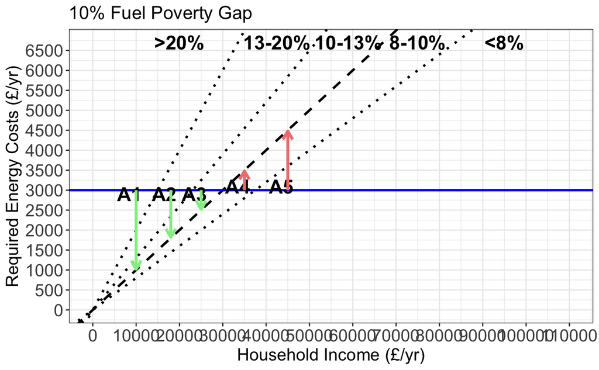

```r
# Visual representation of fuel poverty gap

fg10 <- ggplot(synth_lsoa_subset, aes(x = income, y = energy_costs, color = factor(five_level_10, levels = level_order))) +
  labs(title = "10% Fuel Poverty Gap",
       x = "Household Income (£/yr)",
       y = "Required Energy Costs (£/yr)") +
  theme_bw() +
  scale_x_continuous(breaks = seq(0, 110000, 10000), limits = c(0, 110000)) +
  scale_y_continuous(breaks = seq(0, 6500, 500), limits = c(0, 6700)) +
  theme(axis.text.x = element_text(size = 15),
        axis.text.y = element_text(size = 15),
        legend.text = element_text(size = 15),
        legend.title = element_text(size = 15),
        plot.title = element_text(size = 16),
        axis.title.x = element_text(size = 15),
        axis.title.y = element_text(size = 15)) +
  geom_abline(intercept = 0, slope = (8/100), linetype = "dotted", color = "black", linewidth = 1) +
  geom_abline(intercept = 0, slope = (10/100), linetype = "dashed", color = "black", linewidth = 1) +
  geom_abline(intercept = 0, slope = (13/100), linetype = "dotted", color = "black", linewidth = 1) +
  geom_abline(intercept = 0, slope = (20/100), linetype = "dotted", color = "black", linewidth = 1) +
  geom_hline(yintercept = 3000, color = "blue", linetype = "solid", linewidth = 1) +
  annotate("text", x = 95000, y = 6700, label = "<8%", size = 6, color = "black", fontface = "bold") +
  annotate("text", x = 75000, y = 6700, label = "8-10%", size = 6, color = "black", fontface = "bold") +
  annotate("text", x = 59000, y = 6700, label = "10-13%", size = 6, color = "black", fontface = "bold") +
  annotate("text", x = 42500, y = 6700, label = "13-20%", size = 6, color = "black", fontface = "bold") +
  annotate("text", x = 20000, y = 6700, label = ">20%", size = 6, color = "black", fontface = "bold") +
  annotate("text", x = 8500, y = 2900, label = "A1", size = 6, color = "black", fontface = "bold") +
  annotate("text", x = 16500, y = 2900, label = "A2", size = 6, color = "black", fontface = "bold") +
  annotate("text", x = 23500, y = 2900, label = "A3", size = 6, color = "black", fontface = "bold") +
  annotate("text", x = 33500, y = 3100, label = "A4", size = 6, color = "black", fontface = "bold") +
  annotate("text", x = 43500, y = 3100, label = "A5", size = 6, color = "black", fontface = "bold") +
  annotate("segment", x = 25000, y = 3000, xend = 25000, yend = 2520,
           arrow = arrow(length = unit(0.3, "cm")), color = "#90EE90", linewidth=1.2) +
  annotate("segment", x = 18000, y = 3000, xend = 18000, yend = 1820,
           arrow = arrow(length = unit(0.3, "cm")), color = "#90EE90", linewidth=1.2) +
  annotate("segment", x = 10000, y = 3000, xend = 10000, yend = 1020,
           arrow = arrow(length = unit(0.3, "cm")), color = "#90EE90", linewidth=1.2) +
  annotate("segment", x = 35000, y = 3000, xend = 35000, yend = 3480,
           arrow = arrow(length = unit(0.3, "cm")), color = "#F08080", linewidth=1.2) +
  annotate("segment", x = 45000, y = 3000, xend = 45000, yend = 4480,
           arrow = arrow(length = unit(0.3, "cm")), color = "#F08080", linewidth=1.2)

fg10
```

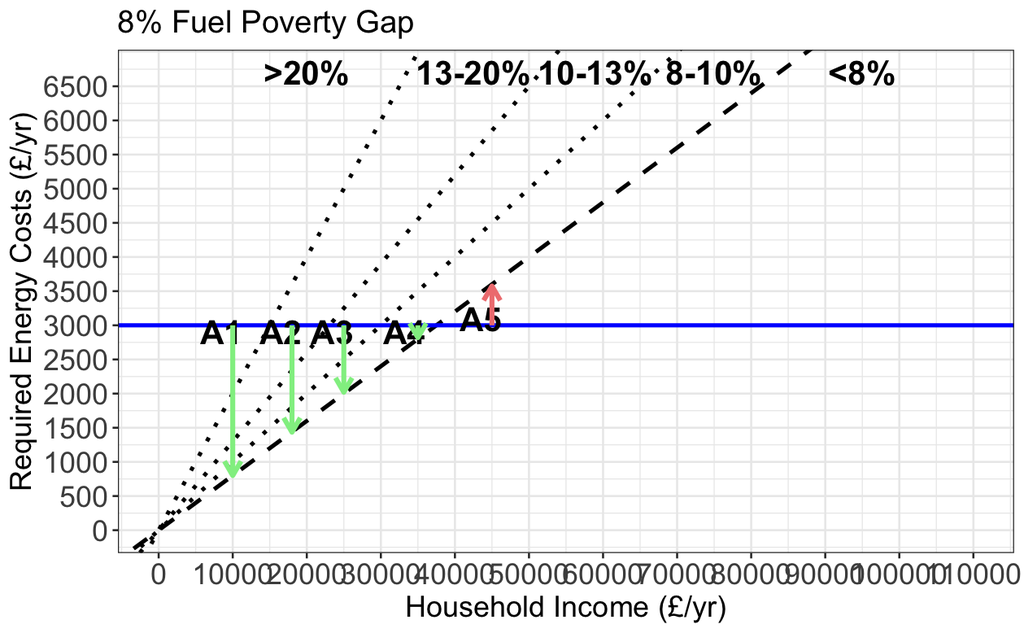

```r
# Visualisation of 8% (marginal) fuel poverty gap (note: can theoretically be done for any of the thresholds, but makes sense to include 8% fuel poverty gap, as this is used as a proxy for precariousness)

fg8 <- ggplot(synth_lsoa_subset, aes(x = income, y = energy_costs, color = factor(five_level_10, levels = level_order))) +
  labs(title = "8% Fuel Poverty Gap",
       x = "Household Income (£/yr)",
       y = "Required Energy Costs (£/yr)") +
  theme_bw() +
  scale_x_continuous(breaks = seq(0, 110000, 10000), limits = c(0, 110000)) +
  scale_y_continuous(breaks = seq(0, 6500, 500), limits = c(0, 6700)) +
  theme(axis.text.x = element_text(size = 15),
        axis.text.y = element_text(size = 15),
        legend.text = element_text(size = 15),
        legend.title = element_text(size = 15),
        plot.title = element_text(size = 16),
        axis.title.x = element_text(size = 15),
        axis.title.y = element_text(size = 15)) +
  geom_abline(intercept = 0, slope = (8/100), linetype = "dashed", color = "black", linewidth = 1) +
  geom_abline(intercept = 0, slope = (10/100), linetype = "dotted", color = "black", linewidth = 1) +
  geom_abline(intercept = 0, slope = (13/100), linetype = "dotted", color = "black", linewidth = 1) +
  geom_abline(intercept = 0, slope = (20/100), linetype = "dotted", color = "black", linewidth = 1) +
  geom_hline(yintercept = 3000, color = "blue", linetype = "solid", linewidth = 1) +
  annotate("text", x = 95000, y = 6700, label = "<8%", size = 6, color = "black", fontface = "bold") +
  annotate("text", x = 75000, y = 6700, label = "8-10%", size = 6, color = "black", fontface = "bold") +
  annotate("text", x = 59000, y = 6700, label = "10-13%", size = 6, color = "black", fontface = "bold") +
  annotate("text", x = 42500, y = 6700, label = "13-20%", size = 6, color = "black", fontface = "bold") +
  annotate("text", x = 20000, y = 6700, label = ">20%", size = 6, color = "black", fontface = "bold") +
  annotate("text", x = 8500, y = 2900, label = "A1", size = 6, color = "black", fontface = "bold") +
  annotate("text", x = 16500, y = 2900, label = "A2", size = 6, color = "black", fontface = "bold") +
  annotate("text", x = 23500, y = 2900, label = "A3", size = 6, color = "black", fontface = "bold") +
  annotate("text", x = 33200, y = 2900, label = "A4", size = 6, color = "black", fontface = "bold") +
  annotate("text", x = 43500, y = 3100, label = "A5", size = 6, color = "black", fontface = "bold") +
  annotate("segment", x = 25000, y = 3000, xend = 25000, yend = 2020,
           arrow = arrow(length = unit(0.3, "cm")), color = "#90EE90", linewidth=1.2) +
  annotate("segment", x = 18000, y = 3000, xend = 18000, yend = 1435,
           arrow = arrow(length = unit(0.3, "cm")), color = "#90EE90", linewidth=1.2) +
  annotate("segment", x = 10000, y = 3000, xend = 10000, yend = 800,
           arrow = arrow(length = unit(0.3, "cm")), color = "#90EE90", linewidth=1.2) +
  annotate("segment", x = 35000, y = 3000, xend = 35000, yend = 2820,
           arrow = arrow(length = unit(0.3, "cm")), color = "#90EE90", linewidth=1.2) +
  annotate("segment", x = 45000, y = 3000, xend = 45000, yend = 3575,
           arrow = arrow(length = unit(0.3, "cm")), color = "#F08080", linewidth=1.2)

fg8
```

```r
# Now calculate 8% and 10% fuel poverty gap and buffer among all Nottingham homes

# 10% gap (positive values) and buffer (negative values)
synth <- synth %>%
  mutate(`10%_fuel_poverty_gap_and_buffer` = energy_costs - (0.10 * income))

# 8% gap (positive values) and buffer (negative values)
synth <- synth %>%
  mutate(`8%_fuel_poverty_gap_and_buffer` = energy_costs - (0.08 * income))




# Create gap vs buffer subsets (e.g. for 10%) to make summary stats more intuitive

# 10% gap
ten_fp_gap <- synth %>%
  filter(`10%_fuel_poverty_gap_and_buffer` >= 0)

colnames(ten_fp_gap)[29] <- "ten_fp_gap"
cols_to_drop <- c(30) # drop 8% to avoid confusion
ten_fp_gap <- ten_fp_gap[, -cols_to_drop]

# Calculate median 10% gap per LSOA and join LSOA summary table
median_ten_fp_gap <- ten_fp_gap %>%
  group_by(lsoa_2011) %>%
  summarise(median_ten_fp_gap = median(ten_fp_gap, na.rm = TRUE))
LSOA_summary_fp <- left_join(LSOA_summary_fp, median_ten_fp_gap, by = "lsoa_2011") # Join


# 10% buffer
ten_fp_buffer <- synth %>%
  filter(`10%_fuel_poverty_gap_and_buffer` < 0)

colnames(ten_fp_buffer)[29] <- "ten_fp_buffer"
cols_to_drop <- c(30) # drop 8% to avoid confusion
ten_fp_buffer <- ten_fp_buffer[, -cols_to_drop]

# Calculate median 10% buffer per LSOA and join LSOA summary table
median_ten_fp_buffer <- ten_fp_buffer %>%
  group_by(lsoa_2011) %>%
  summarise(median_ten_fp_buffer = median(ten_fp_buffer, na.rm = TRUE))
LSOA_summary_fp <- left_join(LSOA_summary_fp, median_ten_fp_buffer, by = "lsoa_2011") # Join

# Summary stats: 10% fuel poverty gap and buffer
ten_gap_summary <- summary(ten_fp_gap$ten_fp_gap)
ten_buffer_summary <- summary(ten_fp_buffer$ten_fp_buffer)
ten_aggregate_gap <- sum(ten_fp_gap$ten_fp_gap, na.rm = TRUE)
ten_aggregate_buffer <- sum(ten_fp_buffer$ten_fp_buffer, na.rm = TRUE)
```

## 11. Calculating MIS-based Fuel Poverty: including MIS + 10% and MIS + five-level 10% + fuel poverty gap/buffer

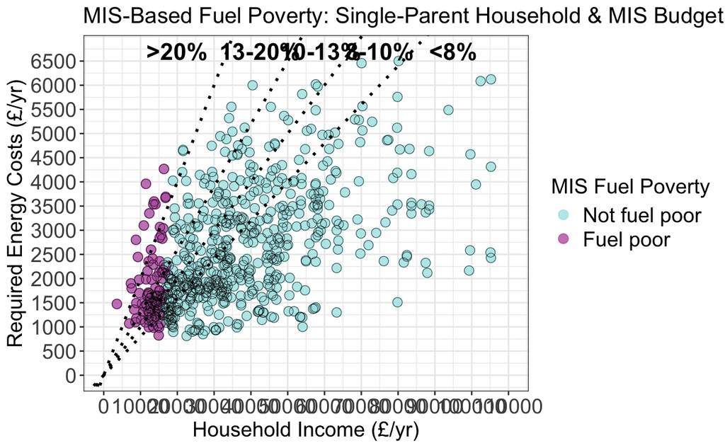

```r
# To estimate MIS-based fuel poverty, household composition (which corresponds to different MIS budgets) must first be inferred for the synthetic Nottingham homes. There are two potential approaches here: 1) Simple Probabilistic Assignment; 2) Weighted Probabilistic Assignment


# Order synth df by total_floor_area:
synth_ordered <- synth %>%
  arrange(desc(total_floor_area))

# Define likely proportion of each household composition of Nottingham (based on ONS data)
household_proportions <- c(
  couple_one_child = 0.159,
  couple = 0.190,
  single_one_child = 0.124,
  pensioner_couple = 0.049,
  single = 0.370,
  single_pensioner = 0.108
)

household_types <- names(household_proportions)

# -----------------------------------------------------------
# -----------------------------------------------------------
# 1: Simple probabilistic assignment (ignoring home size):
# -----------------------------------------------------------
# -----------------------------------------------------------

set.seed(123) # For reproducibility

synth$inferred_household_composition_random <- sample(
  household_types,
  size = nrow(synth),
  replace = TRUE,
  prob = household_proportions
)

# -----------------------------------------------------------
# -----------------------------------------------------------
# 2: Probabilistic assignment weighted by total floor area
# -----------------------------------------------------------
# -----------------------------------------------------------

# Normalize the total floor area to create probabilities
synth_weighted_area <- synth_ordered %>%
  mutate(normalized_area = total_floor_area / max(total_floor_area, na.rm = TRUE))

# Create a probability distribution biased towards larger households for larger homes
assign_composition_weighted_area <- function(normalized_area, proportions, types) { # Define how area influences probability
  biased_probs <- proportions * (1 + 2 * normalized_area)
  biased_probs <- biased_probs / sum(biased_probs)

  sample(types, size = 1, replace = TRUE, prob = biased_probs)
}

set.seed(456) # For reproducibility

synth_weighted_area <- synth_weighted_area %>%
  rowwise() %>%
  mutate(inferred_household_composition = assign_composition_weighted_area(normalized_area, household_proportions, household_types)) %>%
  ungroup()

synth <- synth_weighted_area


# Create new column for MIS budget based on inferred household composition variable
synth <- synth %>%
  mutate(
    mis_budget = case_when(
      inferred_household_composition == "single_pensioner" ~ 10331,
      inferred_household_composition == "single" ~ 11327,
      inferred_household_composition == "single_one_child" ~ 16348,
      inferred_household_composition == "pensioner_couple" ~ 16006,
      inferred_household_composition == "couple" ~ 18945,
      inferred_household_composition == "couple_one_child" ~ 21594,
      TRUE ~ NA_real_ # Assign NA for any other (unexpected) compositions
    )
  )


# -----------------------------------------------------------
# -----------------------------------------------------------
# Calculation of MIS-based fuel poverty
# -----------------------------------------------------------
# -----------------------------------------------------------

# New column: 90% of MIS budget (threshold used by Scot Gov., i.e., residual income should be >90% of MIS after energy costs and housing costs, although housing costs cannot be accounted for here - could isolate rental tenure and deduct assumed MIS rent?)
synth <- synth %>%
  mutate(mis_ninety = mis_budget * 0.9)


# MIS-based fuel poverty
synth <- synth %>%
  mutate(
    mis_fuel_poverty = ifelse((income - energy_costs) < mis_ninety, 1, 0)
  )


# MIS + 10% (Scot Gov. approach)
synth <- synth %>%
  mutate(
    mis_plus_10 = case_when(
      mis_fuel_poverty == 1 | categorical_10 == 1 ~ 1,
      TRUE ~ 0
    )
  )


# Visualise MIS + 10% for example LSOAs

# Overwrite previous LSOA summary df
lsoa_values_to_keep <- c("E01013979", "E01013983", "E01013931", "E01013965",
                          "E01013977", "E01013893", "E01013897", "E01013856",
                          "E01013934", "E01013984", "E01033398")

synth_lsoa_subset <- synth %>%
  filter(lsoa_2011 %in% lsoa_values_to_keep)

# Subset for single parent homes
single_parent_lsoa_subset <- synth_lsoa_subset %>%
  filter(inferred_household_composition == "single_one_child")

# MIS-based fuel poverty among single-parent homes
mis1 <- ggplot(single_parent_lsoa_subset, aes(x = income, y = energy_costs, color = factor(mis_fuel_poverty))) +
  geom_point(size = 3, alpha = 0.8) +
  geom_point(size = 3, alpha = 0.8, shape = 21, stroke = 0.25, color = "black") +
  labs(title = "MIS-Based Fuel Poverty: Single-Parent Household & MIS Budget",
       x = "Household Income (£/yr)",
       y = "Required Energy Costs (£/yr)",
       color = "MIS Fuel Poverty") +
  theme_bw() +
  scale_color_manual(values = c("0" = "#ACE4E4", "1" = "#BB64B1"),
                      labels = c("0" = "Not fuel poor", "1" = "Fuel poor")) +
  scale_x_continuous(breaks = seq(0, 110000, 10000), limits = c(0, 110000)) +
  scale_y_continuous(breaks = seq(0, 6500, 500), limits = c(0, 6700)) +
  theme(axis.text.x = element_text(size = 15),
        axis.text.y = element_text(size = 15),
        legend.text = element_text(size = 15),
        legend.title = element_text(size = 15),
        plot.title = element_text(size = 16),
        axis.title.x = element_text(size = 15),
        axis.title.y = element_text(size = 15)) +
  geom_abline(intercept = 0, slope = (8/100), linetype = "dotted", color = "black", linewidth = 1) +
  geom_abline(intercept = 0, slope = (10/100), linetype = "dotted", color = "black", linewidth = 1) +
  geom_abline(intercept = 0, slope = (13/100), linetype = "dotted", color = "black", linewidth = 1) +
  geom_abline(intercept = 0, slope = (20/100), linetype = "dotted", color = "black", linewidth = 1) +
  annotate("text", x = 95000, y = 6700, label = "<8%", size = 6, color = "black", fontface = "bold") +
  annotate("text", x = 75000, y = 6700, label = "8-10%", size = 6, color = "black", fontface = "bold") +
  annotate("text", x = 59000, y = 6700, label = "10-13%", size = 6, color = "black", fontface = "bold") +
  annotate("text", x = 42500, y = 6700, label = "13-20%", size = 6, color = "black", fontface = "bold") +
  annotate("text", x = 20000, y = 6700, label = ">20%", size = 6, color = "black", fontface = "bold")

mis1
```

```r
# MIS-based FP per LSOA
mis_lsoa <- synth %>%
  group_by(lsoa_2011) %>%
  summarise(
    proportion_mis = mean(mis_fuel_poverty, na.rm = TRUE)
  )

# 10% + MIS-based FP per LSOA
mis_10_lsoa <- synth %>%
  group_by(lsoa_2011) %>%
  summarise(
    proportion_mis_plus_10 = mean(mis_plus_10, na.rm = TRUE)
  )


LSOA_summary_fp <- left_join(LSOA_summary_fp, mis_lsoa, by = "lsoa_2011")
LSOA_summary_fp <- left_join(LSOA_summary_fp, mis_10_lsoa, by = "lsoa_2011")
```